# GRADED ASSIGNMENT 2

# 1. Load the required libraries and read the dataset.

```python
# Load libraries
import pandas as pd
import numpy as np
import matplotlib.pyplot as plt
import seaborn as sns
import warnings
warnings.filterwarnings('ignore')

from sklearn.preprocessing import StandardScaler,LabelEncoder
from sklearn.cluster import KMeans
from scipy.cluster.hierarchy import linkage, dendrogram, fcluster
from sklearn.cluster import AgglomerativeClustering
from sklearn.decomposition import PCA
from sklearn.preprocessing import Normalizer
from sklearn.metrics import silhouette_score
```

```python
pd.set_option('display.max_columns', None)
# Read dataset
df = pd.read_csv("download.csv")
```

# 2. Check the first few samples, shape, info of the data and try to familiarize yourself with different features

```python
# first few samples
df.head(5)
```

|  | Unnamed: 0 | fit | user_id | bust size | item_id | weight | rating | rented for | review_text | body type | review_summary | category | height | size | age | review_date |
| --- | --- | --- | --- | --- | --- | --- | --- | --- | --- | --- | --- | --- | --- | --- | --- | --- |
| 0 | 0 | fit | 420272 | 34d | 2260466 | 137lbs | 10.0 | vacation | An adorable romper! Belt and zipper were a lit... | hourglass | So many compliments! | romper | 5' 8" | 14 | 28.0 | April 20, 2016 |
| 1 | 1 | fit | 273551 | 34b | 153475 | 132lbs | 10.0 | other | I rented this dress for a photo shoot. The the... | straight & narrow | I felt so glamourous!!! | gown | 5' 6" | 12 | 36.0 | June 18, 2013 |
| 2 | 2 | fit | 360448 | NaN | 1063761 | NaN | 10.0 | party | This hugged in all the right places! It was a ... | NaN | It was a great time to celebrate the (almost) ... | sheath | 5' 4" | 4 | 116.0 | December 14, 2015 |
| 3 | 3 | fit | 909926 | 34c | 126335 | 135lbs | 8.0 | formal affair | I rented this for my company's black tie award... | pear | Dress arrived on time and in perfect condition. | dress | 5' 5" | 8 | 34.0 | February 12, 2014 |
| 4 | 4 | fit | 151944 | 34b | 616682 | 145lbs | 10.0 | wedding | I have always been petite in my upper body and... | athletic | Was in love with this dress !!! | gown | 5' 9" | 12 | 27.0 | September 26, 2016 |

Dropping the 'Unnamed: 0' column because it doesn't provide any meaningful information for our analysis and appears to be same as row number

```python
df.drop('Unnamed: 0',axis=1,inplace=True)
```

```python
# Shape (rows, columns)
df.shape
```

```
(192544, 15)
```

```python
# info
df.info()
```

```
<class 'pandas.core.frame.DataFrame'>
RangeIndex: 192544 entries, 0 to 192543
Data columns (total 15 columns):
 #   Column          Non-Null Count   Dtype
---  ------          --------------   -----
 0   fit             192544 non-null  object
 1   user_id         192544 non-null  int64
 2   bust size       174133 non-null  object
 3   item_id         192544 non-null  int64
 4   weight          162562 non-null  object
 5   rating          192462 non-null  float64
 6   rented for      192534 non-null  object
 7   review_text     192476 non-null  object
 8   body type       177907 non-null  object
 9   review_summary  192197 non-null  object
 10  category        192544 non-null  object
 11  height          191867 non-null  object
 12  size            192544 non-null  int64
 13  age             191584 non-null  float64
 14  review_date     192544 non-null  object
dtypes: float64(2), int64(3), object(10)
memory usage: 22.0+ MB
```

```python
# different features
df.describe()
```

|  | user_id | item_id | rating | size | age |
| --- | --- | --- | --- | --- | --- |
| count | 192544.000000 | 1.925440e+05 | 192462.000000 | 192544.000000 | 191584.000000 |
| mean | 499494.100149 | 1.045684e+06 | 9.092371 | 12.245175 | 33.871017 |
| std | 289059.719328 | 8.053148e+05 | 1.430044 | 8.494877 | 8.058083 |
| min | 9.000000 | 1.233730e+05 | 2.000000 | 0.000000 | 0.000000 |
| 25% | 250654.250000 | 1.950760e+05 | 8.000000 | 8.000000 | 29.000000 |
| 50% | 499419.000000 | 9.483960e+05 | 10.000000 | 12.000000 | 32.000000 |
| 75% | 750974.000000 | 1.678888e+06 | 10.000000 | 16.000000 | 37.000000 |
| max | 999997.000000 | 2.966087e+06 | 10.000000 | 58.000000 | 117.000000 |

```python
# statistical summary for object type
df.describe(include = 'O')
```

|  | fit | bust size | weight | rented for | review_text | body type | review_summary | category | height | review_date |
| --- | --- | --- | --- | --- | --- | --- | --- | --- | --- | --- |
| count | 192544 | 174133 | 162562 | 192534 | 192476 | 177907 | 192197 | 192544 | 191867 | 192544 |
| unique | 3 | 106 | 190 | 9 | 191026 | 7 | 154735 | 68 | 24 | 2274 |
| top | fit | 34b | 130lbs | wedding | . | hourglass | Stylist Review | dress | 5' 4" | June 15, 2016 |
| freq | 142058 | 27285 | 14370 | 57784 | 63 | 55349 | 977 | 92884 | 28012 | 844 |

```python
# Null value percentage in a specific dataset column
df.isnull().sum()/len(df) * 100
```

```
fit                0.000000
user_id            0.000000
bust size          9.561970
item_id            0.000000
weight            15.571506
rating             0.042588
rented for         0.005194
review_text        0.035317
body type          7.601899
review_summary     0.180219
category           0.000000
height             0.351608
size               0.000000
age                0.498587
review_date        0.000000
dtype: float64
```

1. The dataset has missing values in certain columns such as 'bust size', 'weight', 'body type', 'review_text', 'review_summary', 'height', 'age', and 'rating'.
2. Dataset have integers, floats, and objects
3. Categorical columns - 'fit', 'rented for', 'body type', 'category', and 'review_date'
4. Numerical like- 'rating', 'size', and 'age'
5. Before proceeding with analysis or modeling tasks, it may be necessary to handle missing values and perform data cleaning and preprocessing.

# 3. Check if there are any duplicate records in the dataset? If any, drop them.

```python
# checking number of duplicates
len(df[df.duplicated()])
```

```
189
```

```python
# Dropping 189 duplicates
df.drop_duplicates(inplace=True)
```

```python
# now number of duplicates is
len(df[df.duplicated()])
```

```
0
```

# 4. Drop the columns which you think redundant for the analysis.(Hint: drop columns like ‘id’, ‘review’)

```python
# first lets see all the columns
df.columns
```

```
Index(['fit', 'user_id', 'bust size', 'item_id', 'weight', 'rating',
       'rented for', 'review_text', 'body type', 'review_summary', 'category',
       'height', 'size', 'age', 'review_date'],
      dtype='object')
```

```python
# Dropping redundant columns
df=df.drop(['user_id', 'item_id','review_text',
            'review_summary','review_date'],axis=1)
```

```python
# after dropping redundant columns and duplicate records, new dataset has (rows , column)
df.shape
```

```
(192355, 10)
```

# 5. Check the column 'weight', Is there any presence of string data? If yes, remove the string data and convert to float. (Hint: 'weight' has the suffix as lbs)

```python
# check weight column
df[['weight']].head()
```

|  | weight |
| --- | --- |
| 0 | 137lbs |
| 1 | 132lbs |
| 2 | NaN |
| 3 | 135lbs |
| 4 | 145lbs |

```python
# converting to float type and removing lbs unit
df['weight'] = [float(x.strip('lbs')) if isinstance(x, str) else x for x in df['weight']]

# renaming column to 'weight (lbs)' for better readability
df.rename(columns={'weight': 'weight (lbs)'}, inplace=True)
```

```python
# Displaying 'weight (lbs)' column
df[['weight (lbs)']].head()
```

|  | weight (lbs) |
| --- | --- |
| 0 | 137.0 |
| 1 | 132.0 |
| 2 | NaN |
| 3 | 135.0 |
| 4 | 145.0 |

```python
# Now datatype of weight column is
df['weight (lbs)'].dtype
```

```
dtype('float64')
```

# 6. Check the unique categories for the column 'rented for' and group 'party: cocktail' category with 'party'.

```python
# checking unique categories for the column 'rented for'
df['rented for'].unique()
```

```
array(['vacation', 'other', 'party', 'formal affair', 'wedding', 'date',
       'everyday', 'work', nan, 'party: cocktail'], dtype=object)
```

```python
# grouping 'party: cocktail' category with 'party'
df['rented for'] = df['rented for'].replace({'party: cocktail':'party'})
```

```python
# now, unique values after grouping are
df['rented for'].unique()
```

```
array(['vacation', 'other', 'party', 'formal affair', 'wedding', 'date',
       'everyday', 'work', nan], dtype=object)
```

# 7. The column 'height' is in feet with a quotation mark, Convert to inches with float datatype.

```python
# Converting height in feet to inches and converting to float
df['height'] = df['height'].apply(lambda x: np.nan if pd.isna(x)
                                  else (float(x.split("'")[0]) * 12 + float(x.split("'")[1].strip('"'))))
```

```python
# Renaming the 'height' column to 'height (inches)' for enhanced dataset comprehension.
df.rename(columns={'height': 'height (inches)'}, inplace=True)
```

```python
# new height column after coverting
df[['height (inches)']].head()
```

|  | height (inches) |
| --- | --- |
| 0 | 68.0 |
| 1 | 66.0 |
| 2 | 64.0 |
| 3 | 65.0 |
| 4 | 69.0 |

# 8. Check for missing values in each column of the dataset? If it exists, impute them with appropriate methods.

```python
# percentage of missing values for each column
df.isnull().sum()/len(df) * 100
```

```
fit                 0.000000
bust size           9.561488
weight (lbs)       15.572769
rating              0.042110
rented for          0.005199
body type           7.603130
category            0.000000
height (inches)     0.350914
size                0.000000
age                 0.499077
dtype: float64
```

```python
# Selecting object(categorical) columns
categorical_columns = df.select_dtypes(include=['object']).columns

# non-object(numerical) columns
numerical_columns = df.select_dtypes(exclude=['object']).columns

# for numerical columns imputing missing values with median
for column in numerical_columns:
    df[column] = df[column].fillna(df[column].median())

# for categorical columns, with mode
for column in categorical_columns:
    df[column] = df[column].fillna(df[column].mode().iloc[0])
```

```python
# now the percentage of  missing values in each column is
df.isnull().sum()/len(df) * 100
```

```
fit                0.0
bust size          0.0
weight (lbs)       0.0
rating             0.0
rented for         0.0
body type          0.0
category           0.0
height (inches)    0.0
size               0.0
age                0.0
dtype: float64
```

# 9. Check the statistical summary for the numerical and categorical columns and write your findings.

```python
# statistical summary for numerical col
df.describe()
```

|  | weight (lbs) | rating | height (inches) | size | age |
| --- | --- | --- | --- | --- | --- |
| count | 192355.000000 | 192355.000000 | 192355.000000 | 192355.000000 | 192355.000000 |
| mean | 137.019875 | 9.092709 | 65.309334 | 12.245801 | 33.860633 |
| std | 20.143567 | 1.429922 | 2.658946 | 8.496299 | 8.039386 |
| min | 50.000000 | 2.000000 | 54.000000 | 0.000000 | 0.000000 |
| 25% | 125.000000 | 8.000000 | 63.000000 | 8.000000 | 29.000000 |
| 50% | 135.000000 | 10.000000 | 65.000000 | 12.000000 | 32.000000 |
| 75% | 145.000000 | 10.000000 | 67.000000 | 16.000000 | 37.000000 |
| max | 300.000000 | 10.000000 | 78.000000 | 58.000000 | 117.000000 |

```python
# statistical summary for categorical col
df.describe(include='O')
```

|  | fit | bust size | rented for | body type | category |
| --- | --- | --- | --- | --- | --- |
| count | 192355 | 192355 | 192355 | 192355 | 192355 |
| unique | 3 | 106 | 8 | 7 | 68 |
| top | fit | 34b | wedding | hourglass | dress |
| freq | 141909 | 45647 | 57747 | 69915 | 92752 |

## Numerical Columns:

The dataset includes 5 columns that contain numerical data, providing valuable insights into customer characteristics and preferences. However, it is worth noting that there are some minimum values of 0 in certain numerical columns, which could suggest potential data anomalies or outliers that require further investigation.

On the other hand, the maximum values in the dataset represent the upper limits of the respective column ranges, which give us an idea of the scale and variability of the numerical data.

According to the dataset, the average weight of customers is around 137 lbs, and they generally give a high satisfaction rating of approximately 9. Regarding height, the customers vary from a minimum of 54 inches to a maximum of 78 inches.

Lastly, it is important to mention that the age range observed in the dataset is quite wide, extending up to 117 years, which could indicate the presence of outliers in the 'age' column.

## Categorical Columns:

Out of the 5 object type columns, the 'fit' column provides insights into the satisfaction levels of customers regarding product sizes. The majority of customers reported that the products fit well.

The 'body type', 'category', and 'rented for' columns offer valuable information on customer preferences and popular product categories. For instance, the 'hourglass' body type is the most frequent, and 'dress' is the most rented category.

Understanding the frequent occurrences in these categorical columns is essential for businesses to tailor their inventory management and marketing strategies to meet customer demands effectively. This will enhance customer satisfaction and loyalty.

# 10. Are there outliers present in the column age? If yes, treat them with the appropriate method.

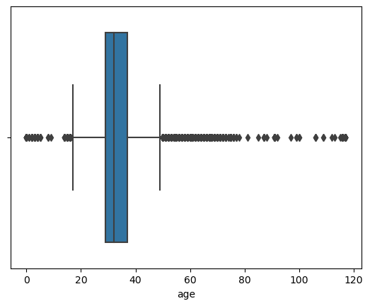

```python
# Plotting the box-plot of age column to check for outliers
sns.boxplot(x= df['age'])
```

```python
# there is presence of outliers as its evident from above plot
# IQR treatment for outliers:

Q1 = df['age'].quantile(0.25)
Q2 = df['age'].quantile(0.5)
Q3 = df['age'].quantile(0.75)

IQR = Q3 - Q1

lower_range = Q1 - (1.5*IQR)
upper_range = Q3 + (1.5*IQR)

df = df.loc[(df['age'] > lower_range) & (df['age'] < upper_range)]
```

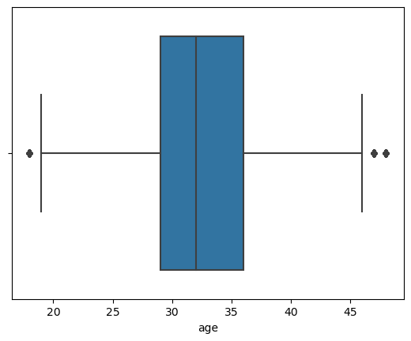

```python
# boxplot after treatment:
sns.boxplot(x=df['age'])
```

# 11. Check the distribution of the different categories in the column 'rented for' using appropriate plot.

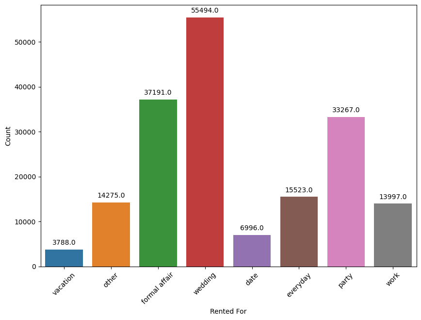

```python
# distribution of different categories in the 'rented for' column
plt.figure(figsize=(10, 7))
ax = sns.countplot(data=df, x='rented for')

plt.xlabel('Rented For')
plt.ylabel('Count')
plt.xticks(rotation=45)

# Annotating each count bar
for p in ax.patches:
    ax.annotate(f'{p.get_height()}', (p.get_x() + p.get_width() / 2., p.get_height()), ha='center', va='center', xytext=(0, 10), textcoords='offset points')

plt.show()
```

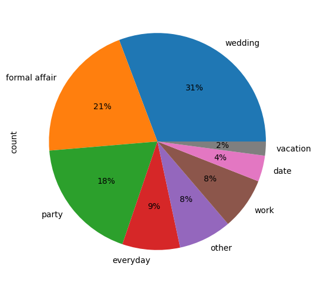

```python
# since a pie chart is considered great to show distribution
plt.figure(figsize=(10, 6))
df['rented for'].value_counts().plot(kind='pie',autopct='%1.0f%%')
plt.show()
```

# 12. Encode the categorical variables in the dataset

```python
# copy of the cleaned dataset.
df_cleaned = df.copy()
```

```python
df.select_dtypes('object').columns
```

```
Index(['fit', 'bust size', 'rented for', 'body type', 'category'], dtype='object')
```

```python
# Iterating through each column with object datatype and applying label encoding
for col in df.select_dtypes('object').columns:

# Initializing a new LabelEncoder object for each column
    le = LabelEncoder()

# Fit-transforming the column and replacing the original values
    df[col] = le.fit_transform(df[col])
```

```python
df.head()
```

|  | fit | bust size | weight (lbs) | rating | rented for | body type | category | height (inches) | size | age |
| --- | --- | --- | --- | --- | --- | --- | --- | --- | --- | --- |
| 0 | 0 | 39 | 137.0 | 10.0 | 5 | 3 | 44 | 68.0 | 14 | 28.0 |
| 1 | 0 | 37 | 132.0 | 10.0 | 3 | 6 | 20 | 66.0 | 12 | 36.0 |
| 3 | 0 | 38 | 135.0 | 8.0 | 2 | 4 | 16 | 65.0 | 8 | 34.0 |
| 4 | 0 | 37 | 145.0 | 10.0 | 6 | 1 | 20 | 69.0 | 12 | 27.0 |
| 5 | 0 | 24 | 138.0 | 8.0 | 0 | 1 | 16 | 68.0 | 8 | 45.0 |

# 13. Standardize the data, so that the values are within a particular range

```python
df1 = df.copy()
```

```python
# StandardScaler object
ss = StandardScaler()

# Fit and transform the data
scaled_features = ss.fit_transform(df1)

# Convert the scaled array back to a DataFrame
scaled_features_df = pd.DataFrame(scaled_features, index=df1.index, columns= df1.columns)

scaled_features_df.head(5)
```

|  | fit | bust size | weight (lbs) | rating | rented for | body type | category | height (inches) | size | age |
| --- | --- | --- | --- | --- | --- | --- | --- | --- | --- | --- |
| 0 | -0.556782 | 0.019717 | 0.005575 | 0.636126 | 0.502733 | 0.016789 | 1.578749 | 1.008246 | 0.233626 | -0.769957 |
| 1 | -0.556782 | -0.164502 | -0.243996 | 0.636126 | -0.468085 | 1.926202 | -0.304798 | 0.258112 | -0.004654 | 0.585645 |
| 3 | -0.556782 | -0.072393 | -0.094253 | -0.766009 | -0.953494 | 0.653260 | -0.618723 | -0.116955 | -0.481213 | 0.246745 |
| 4 | -0.556782 | -0.164502 | 0.404890 | 0.636126 | 0.988142 | -1.256154 | -0.304798 | 1.383314 | -0.004654 | -0.939407 |
| 5 | -0.556782 | -1.361931 | 0.055490 | -0.766009 | -1.924313 | -1.256154 | -0.618723 | 1.008246 | -0.481213 | 2.110698 |

# 14. Apply PCA on the above dataset and determine the number of PCA components to be used so that 90-95% of the variance in data is explained by the same.

```python
# 1)Covariance Matrix
cov_matrix = np.cov(scaled_features.T)
print('Covariance matrix','\n',cov_matrix)
```

```
Covariance matrix
 [[ 1.00000554e+00  8.85382387e-03  1.47179578e-02 -2.43976724e-01
   7.51853608e-03 -8.17094537e-03  2.92230406e-04  1.41966736e-04
   6.57803423e-02 -1.81644662e-03]
 [ 8.85382387e-03  1.00000554e+00  5.68054989e-01 -2.09808478e-02
   5.85676356e-04 -2.17280915e-01 -1.29132056e-02  1.48479410e-01
   6.26687911e-01  1.47335159e-01]
 [ 1.47179578e-02  5.68054989e-01  1.00000554e+00 -2.13609762e-02
   9.82928796e-03 -2.37264407e-01 -1.75365753e-02  3.51571202e-01
   7.22089712e-01  6.91620017e-02]
 [-2.43976724e-01 -2.09808478e-02 -2.13609762e-02  1.00000554e+00
   1.25426644e-02  5.19818763e-03 -2.40478681e-02  1.18467962e-03
  -3.78392329e-02 -5.02524467e-02]
 [ 7.51853608e-03  5.85676356e-04  9.82928796e-03  1.25426644e-02
   1.00000554e+00 -1.12759624e-02 -5.87182956e-02 -1.73982232e-02
   6.60761996e-03 -1.83755128e-02]
 [-8.17094537e-03 -2.17280915e-01 -2.37264407e-01  5.19818763e-03
  -1.12759624e-02  1.00000554e+00 -2.01534595e-03 -1.35661479e-01
  -2.16199683e-01 -4.64856865e-02]
 [ 2.92230406e-04 -1.29132056e-02 -1.75365753e-02 -2.40478681e-02
  -5.87182956e-02 -2.01534595e-03  1.00000554e+00 -5.21877028e-03
  -8.67091257e-03  2.19753778e-02]
 [ 1.41966736e-04  1.48479410e-01  3.51571202e-01  1.18467962e-03
  -1.73982232e-02 -1.35661479e-01 -5.21877028e-03  1.00000554e+00
   2.33082719e-01 -2.14980241e-03]
 [ 6.57803423e-02  6.26687911e-01  7.22089712e-01 -3.78392329e-02
   6.60761996e-03 -2.16199683e-01 -8.67091257e-03  2.33082719e-01
   1.00000554e+00  1.30061056e-01]
 [-1.81644662e-03  1.47335159e-01  6.91620017e-02 -5.02524467e-02
  -1.83755128e-02 -4.64856865e-02  2.19753778e-02 -2.14980241e-03
   1.30061056e-01  1.00000554e+00]]
```

```python
# 2)Eigen values and Eigen vectors
eig_vals, eig_vectors = np.linalg.eig(cov_matrix)
print('Eigen vectors:','\n',eig_vectors)
print('\n')
print('Eigen values:','\n',eig_vals)
```

```
Eigen vectors:
 [[-0.03841136 -0.0518874   0.03696811 -0.68366233 -0.68374906  0.18178638
   0.12996611  0.0958963  -0.01730167 -0.01121361]
 [-0.49555814 -0.11879544  0.78415133  0.02051602  0.05195457 -0.04340195
  -0.17410381  0.23272473 -0.18742307 -0.0284994 ]
 [-0.54450001 -0.66798932 -0.46570875  0.05116904  0.03588348  0.04366151
   0.08406834 -0.00748673 -0.16522255 -0.01382422]
 [ 0.03810833 -0.00598031 -0.00158885  0.70134972 -0.69990342 -0.02886377
  -0.02765953  0.10593484 -0.05981102  0.01885547]
 [-0.0035786   0.00376476  0.01594884  0.04310543  0.02630685  0.63390469
  -0.33957707 -0.18944215 -0.08134665  0.6614493 ]
 [ 0.25727748 -0.02088759  0.02560182 -0.04567268 -0.01064743 -0.02146323
  -0.08939928 -0.34093474 -0.86888505 -0.22553619]
 [ 0.01169797 -0.0073344   0.00441961 -0.09518689 -0.04162226 -0.64050161
   0.21049445  0.0026137  -0.18140237  0.70818995]
 [-0.27548667  0.10951287  0.22170989  0.09645008 -0.07113689  0.07607407
   0.50046548 -0.75137626  0.16523496 -0.021768  ]
 [-0.54499104  0.72296203 -0.33547981 -0.01689937 -0.01350801  0.00194023
  -0.05852514  0.11832566 -0.22215295 -0.02267295]
 [-0.12555758 -0.04217132 -0.06497356 -0.12281037 -0.17565529 -0.37947512
  -0.72350572 -0.44120965  0.25011508 -0.08725105]]


Eigen values:
 [2.54864858 0.25952724 0.41760172 1.24922751 0.74926837 1.07087105
 1.01707486 0.85344244 0.89064147 0.94375215]
```

```python
# 3) To calculate the variance explained and the cumulative variance explained
total = sum(eig_vals)
var_exp = [(i/total)*100 for i in sorted(eig_vals, reverse = True)]
cum_var_exp = np.cumsum(var_exp)
print('Explained Variance: ',var_exp)
print('\n')
print('Cummulative Variance Explained: ',cum_var_exp)
```

```
Explained Variance:  [25.486344621477958, 12.492205876030527, 10.708651167610455, 10.17069230922249, 9.437469265414526, 8.90636534091158, 8.534377147524825, 7.492642188703859, 4.175994020770715, 2.595258062333074]


Cummulative Variance Explained:  [ 25.48634462  37.9785505   48.68720167  58.85789397  68.29536324
  77.20172858  85.73610573  93.22874792  97.40474194 100.        ]
```

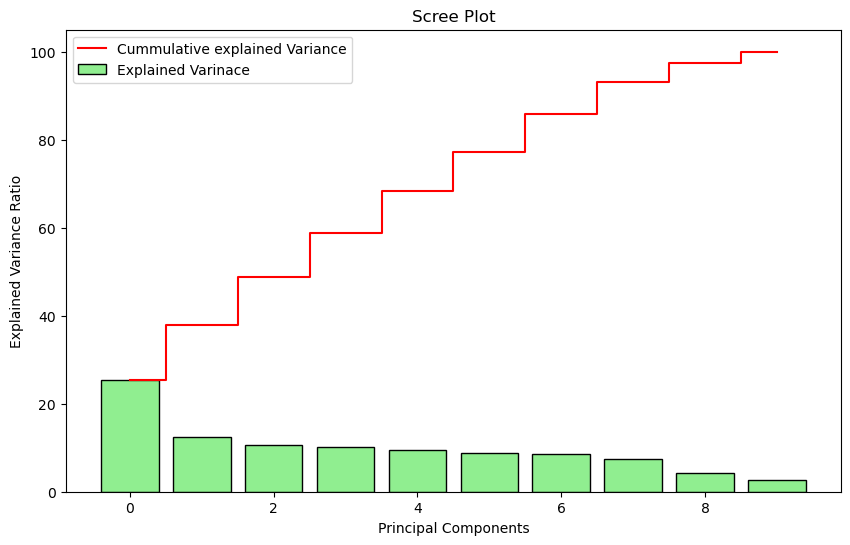

```python
# 4) Scree Plot
plt.figure(figsize=(10, 6))
plt.bar(range(10),var_exp, align='center',color='lightgreen',edgecolor='black',label='Explained Varinace')
plt.step(range(10), cum_var_exp, where='mid',color='red',label='Cummulative explained Variance')
plt.legend(loc = 'best')
plt.title('Scree Plot')
plt.xlabel('Principal Components')
plt.ylabel('Explained Variance Ratio')
plt.show()
```

# 15. Apply K-means clustering and segment the data. (You may use original data or PCA transformed data)

## a. Find the optimal K Value using elbow plot for K Means clustering.

```python
# Principal Component Analysis with 8 components
pca = PCA(n_components=8)

# Transforming the standardized features using PCA
# creating a DataFrame with the transformed components
pca_df = pd.DataFrame(pca.fit_transform(scaled_features_df), columns=['PC1', 'PC2', 'PC3', 'PC4', 'PC5', 'PC6', 'PC7', 'PC8'])

pca_df.head()
```

|  | PC1 | PC2 | PC3 | PC4 | PC5 | PC6 | PC7 | PC8 |
| --- | --- | --- | --- | --- | --- | --- | --- | --- |
| 0 | 0.254599 | -0.885970 | 0.443721 | 1.115166 | 1.504334 | 0.452784 | -0.468511 | -0.055600 |
| 1 | -0.611581 | -0.684848 | 0.468541 | -0.453507 | -0.990210 | 1.347387 | -1.044176 | -0.223136 |
| 2 | -0.507130 | 0.208391 | 0.405696 | -0.120239 | -1.229101 | 0.143924 | -0.272315 | 0.874879 |
| 3 | 0.684194 | -1.221987 | -1.215521 | 1.057551 | 0.790346 | -0.996529 | -0.412511 | 0.060181 |
| 4 | -0.032850 | 0.302211 | 1.539338 | -0.168226 | -1.593051 | -2.463183 | -1.406488 | 0.400590 |

```python
# optimal K Value using elbow plot for K Means clustering
cluster_errors = []
cluster_range = range(2,15)

for num_clusters in cluster_range:
    cluster = KMeans(num_clusters, random_state=100)
    cluster.fit(pca_df)
    cluster_errors.append(cluster.inertia_)

# dataframe of number of clusters and cluster errors
cluster_df = pd.DataFrame({'num_clusters': cluster_range, 'cluster_errors': cluster_errors})
cluster_df
```

|  | num_clusters | cluster_errors |
| --- | --- | --- |
| 0 | 2 | 1.402898e+06 |
| 1 | 3 | 1.273783e+06 |
| 2 | 4 | 1.170838e+06 |
| 3 | 5 | 1.082119e+06 |
| 4 | 6 | 1.026597e+06 |
| 5 | 7 | 9.750221e+05 |
| 6 | 8 | 9.325053e+05 |
| 7 | 9 | 9.021040e+05 |
| 8 | 10 | 8.745739e+05 |
| 9 | 11 | 8.519441e+05 |
| 10 | 12 | 8.290931e+05 |
| 11 | 13 | 8.099142e+05 |
| 12 | 14 | 7.926245e+05 |

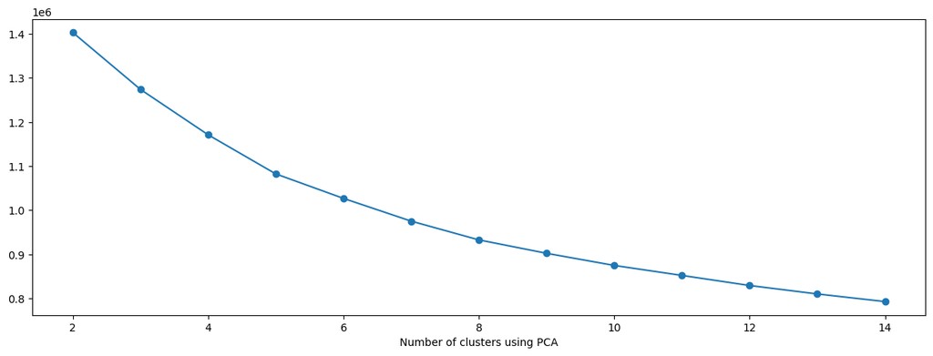

```python
# Elbow plot

plt.figure(figsize=[15,5])
plt.xlabel('Number of clusters using PCA')
plt.plot(cluster_df['num_clusters'], cluster_df['cluster_errors'], marker='o')
```

After applying the elbow method and analyzing the plot, it has been determined that the ideal K value or the number of clusters for our dataset would either be 4 or 5.

For our analysis, we have chosen K=5 as it is the most optimal number of clusters.

Each of the clusters has been assigned a label ranging from 0 to 4.

## b. Build a Kmeans clustering model using the obtained optimal K value from the elbow plot.

```python
# Use KMeans clustering for the optimal number of clusters determined earlier.
kmeans = KMeans(n_clusters=5, random_state=100)
kmeans.fit(pca_df)
```

```
KMeans(n_clusters=5, random_state=100)
```

```python
# Checking the cluster labels
label = pd.DataFrame(kmeans.labels_, columns=['Label'])
kmeans_df = pca_df.join(label)
kmeans_df.head()
```

|  | PC1 | PC2 | PC3 | PC4 | PC5 | PC6 | PC7 | PC8 | Label |
| --- | --- | --- | --- | --- | --- | --- | --- | --- | --- |
| 0 | 0.254599 | -0.885970 | 0.443721 | 1.115166 | 1.504334 | 0.452784 | -0.468511 | -0.055600 | 3 |
| 1 | -0.611581 | -0.684848 | 0.468541 | -0.453507 | -0.990210 | 1.347387 | -1.044176 | -0.223136 | 2 |
| 2 | -0.507130 | 0.208391 | 0.405696 | -0.120239 | -1.229101 | 0.143924 | -0.272315 | 0.874879 | 1 |
| 3 | 0.684194 | -1.221987 | -1.215521 | 1.057551 | 0.790346 | -0.996529 | -0.412511 | 0.060181 | 1 |
| 4 | -0.032850 | 0.302211 | 1.539338 | -0.168226 | -1.593051 | -2.463183 | -1.406488 | 0.400590 | 1 |

```python
# Number of data points assigned to each cluster
kmeans_df['Label'].value_counts()
```

```
Label
1    62063
2    37340
4    28398
0    27463
3    25267
Name: count, dtype: int64
```

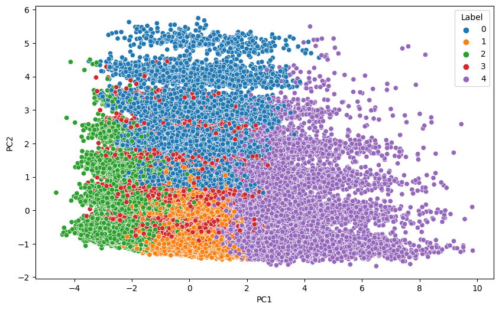

```python
# Clusters formed
plt.figure(figsize=(10, 6))
sns.scatterplot(data=kmeans_df, x='PC1', y='PC2', hue='Label', palette='tab10')
plt.show()
```

## c. Compute silhouette score for evaluating the quality of the K Means clustering technique.

```python
pca_df_20k = pca_df.sample(20000)
```

Only 20000 samples are choosen to reduce the time to compute the result

```python
# optimal clusters with silhoutte score
print("Cluster --> Silhouette Score")
for i in range(2,15):
    kmeans = KMeans(i,random_state=100)
    kmeans.fit(pca_df_20k)
    labels = kmeans.predict(pca_df_20k)
    print(i, "      =  ", silhouette_score(pca_df_20k,labels))
```

```
Cluster --> Silhouette Score
2       =   0.15766176617027647
3       =   0.16027912355105936
4       =   0.15873239152448831
5       =   0.13545412736108983
6       =   0.12053038175334295
7       =   0.12887323657975222
8       =   0.12737398524026863
9       =   0.1167663816913329
10       =   0.12125043091557623
11       =   0.11788422667676289
12       =   0.12022371628249111
13       =   0.12241196573144934
14       =   0.12124968654769966
```

According to the silhouette scores, the optimal value of K appears to be 3, as it has the highest silhouette score among the values tested.

In 15.a we had K=5, due to bend / chnage in inertia around there.

Now after the silhouette scores, we got K=3, the silhouette score is the highest among the tested values.

So, we have two potential optimal K values: 3 or 5, depending on what we prioritize, the elbow method or silhouette score.

# 16. Apply Agglomerative clustering and segment the data. (You may use original data or PCA transformed data)

## a. Find the optimal K Value using dendrogram for Agglomerative clustering.

```python
df2 = scaled_features_df.head(5000)
df2.head()
```

|  | fit | bust size | weight (lbs) | rating | rented for | body type | category | height (inches) | size | age |
| --- | --- | --- | --- | --- | --- | --- | --- | --- | --- | --- |
| 0 | -0.556782 | 0.019717 | 0.005575 | 0.636126 | 0.502733 | 0.016789 | 1.578749 | 1.008246 | 0.233626 | -0.769957 |
| 1 | -0.556782 | -0.164502 | -0.243996 | 0.636126 | -0.468085 | 1.926202 | -0.304798 | 0.258112 | -0.004654 | 0.585645 |
| 3 | -0.556782 | -0.072393 | -0.094253 | -0.766009 | -0.953494 | 0.653260 | -0.618723 | -0.116955 | -0.481213 | 0.246745 |
| 4 | -0.556782 | -0.164502 | 0.404890 | 0.636126 | 0.988142 | -1.256154 | -0.304798 | 1.383314 | -0.004654 | -0.939407 |
| 5 | -0.556782 | -1.361931 | 0.055490 | -0.766009 | -1.924313 | -1.256154 | -0.618723 | 1.008246 | -0.481213 | 2.110698 |

Only 5000 records are taken to decrese time to compute These 5000 records are taken from original scaled data and new dataframe "df2" is created

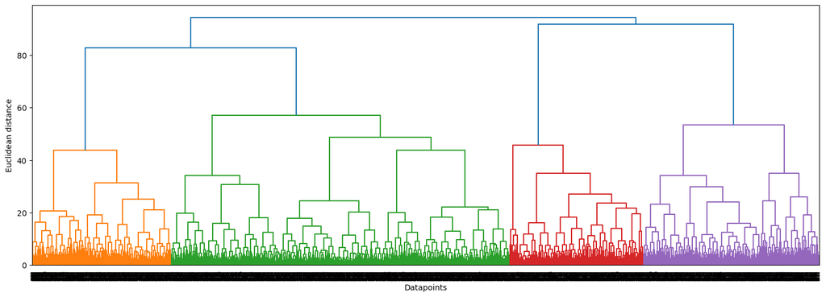

```python
# Dendrogram for Agglomerative clustering
plt.figure(figsize=[18,6])
merge = linkage(df2, method='ward')
dendrogram(merge, leaf_rotation = 90)
plt.xlabel('Datapoints')
plt.ylabel('Euclidean distance')
plt.show()
```

## b. Build a Agglomerative clustering model using the obtained optimal K value observed from dendrogram.

```python
# hierarchical clustering model with optimal clusters as 4
hie_cluster = AgglomerativeClustering(n_clusters=4, affinity='euclidean',
                                     linkage='ward')
hie_cluster_model = hie_cluster.fit(df2)
```

```python
# Dataframe of the labels
df_label1 = pd.DataFrame(hie_cluster_model.labels_,columns=['Labels'])
df_label1.head(5)
```

|  | Labels |
| --- | --- |
| 0 | 3 |
| 1 | 0 |
| 2 | 0 |
| 3 | 2 |
| 4 | 0 |

```python
# Joining label dataframe with df_cleaned
df_hier = df_cleaned.join(df_label1)
df_hier.head()
```

|  | fit | bust size | weight (lbs) | rating | rented for | body type | category | height (inches) | size | age | Labels |
| --- | --- | --- | --- | --- | --- | --- | --- | --- | --- | --- | --- |
| 0 | fit | 34d | 137.0 | 10.0 | vacation | hourglass | romper | 68.0 | 14 | 28.0 | 3.0 |
| 1 | fit | 34b | 132.0 | 10.0 | other | straight & narrow | gown | 66.0 | 12 | 36.0 | 0.0 |
| 3 | fit | 34c | 135.0 | 8.0 | formal affair | pear | dress | 65.0 | 8 | 34.0 | 2.0 |
| 4 | fit | 34b | 145.0 | 10.0 | wedding | athletic | gown | 69.0 | 12 | 27.0 | 0.0 |
| 5 | fit | 32b | 138.0 | 8.0 | date | athletic | dress | 68.0 | 8 | 45.0 | 0.0 |

## c. Compute silhouette score for evaluating the quality of the Agglomerative clustering technique. (Hint: Take a sample of the dataset for agglomerative clustering to reduce the computational time)

```python
for i in range(2,15):
    hier = AgglomerativeClustering(n_clusters=i)
    hier = hier.fit(df2)
    labels = hier.fit_predict(df2)
    print(i,silhouette_score(df2,labels))
```

```
2 0.10596947830186028
3 0.11208921858392236
4 0.11265768073941083
5 0.06409457844924754
6 0.07254276489615602
7 0.04934046809807843
8 0.0527712196185887
9 0.05819176417567287
10 0.05474221813068482
11 0.0455199594918867
12 0.048192625674926055
13 0.05072246139609499
14 0.050119796234222906
```

# 17. Perform cluster analysis by doing bivariate analysis between cluster labels and different features and write your conclusion on the results.

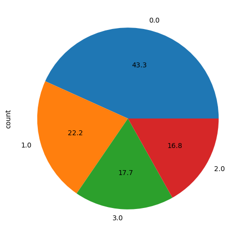

```python
plt.figure(figsize=(6, 6))
df_hier['Labels'].value_counts().plot(kind='pie', autopct='%0.1f')
plt.show()
```

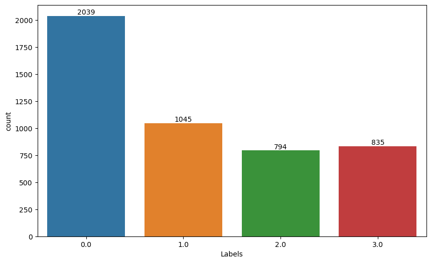

```python
plt.figure(figsize=(10, 6))
sns.countplot(x='Labels', data=df_hier)

# to add the count above each bar
for i in range(len(df_hier['Labels'].value_counts())):
    plt.text(i, df_hier['Labels'].value_counts()[i], df_hier['Labels'].value_counts()[i],
             ha='center', va='bottom')
plt.show()
```

### Bivariate analysis for categorical features

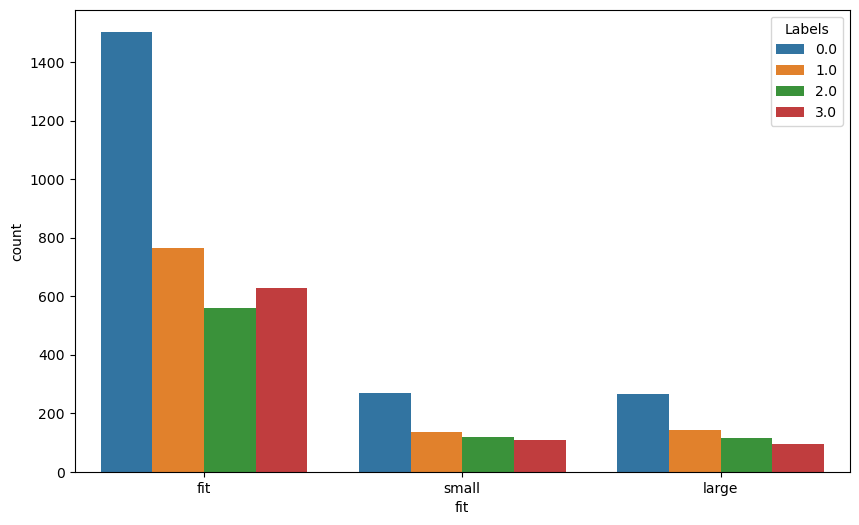

```python
# fit
plt.figure(figsize=(10, 6))
sns.countplot(x='fit', hue='Labels', data=df_hier)
plt.show()
```

The majority of users prefer the 'fit' size, with fewer choosing 'small' or 'large' sizes. Cluster 0 has a higher concentration of customers in all 'fit' statuses compared to other clusters.

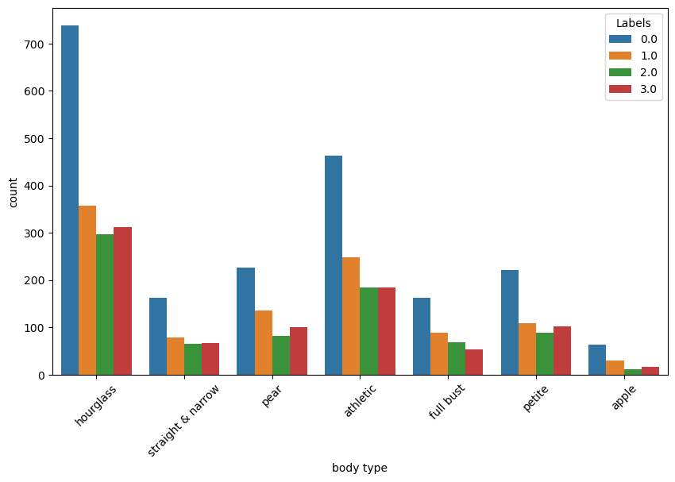

```python
# body type
plt.figure(figsize=(10, 6))
sns.countplot(x='body type', hue='Labels', data=df_hier)
plt.xticks(rotation=45)
plt.show()
```

It seems that there are more customers with an 'hourglass' and 'athletic' body type compared to 'apple' body type. Moreover, cluster 0 has a higher number of customers across all body types than other clusters.

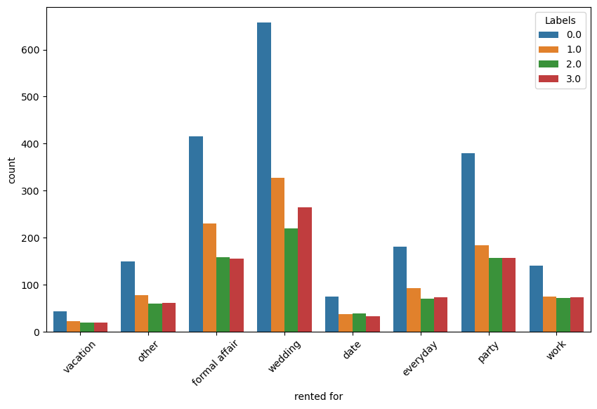

```python
# rented for
plt.figure(figsize=(10, 6))
sns.countplot(x='rented for', hue='Labels', data=df_hier)
plt.xticks(rotation=45)
plt.show()
```

The majority of customers rent products for weddings, indicating a prevalent preference for such occasions. Additionally, cluster 0 has a larger proportion of users compared to clusters 1, 2, and 3 for all rental purposes.

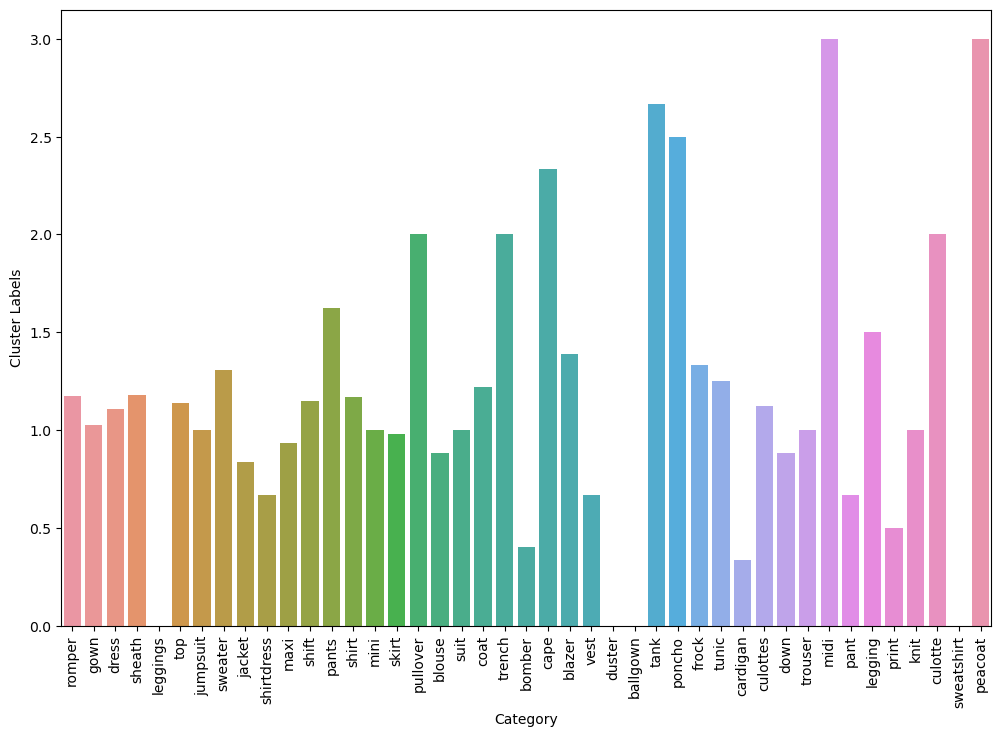

```python
# 'category'

# Drop rows with non-finite values in the 'Labels' column
df_hier.dropna(subset=['Labels'], inplace=True)

# Convert 'Labels' column to integer type
df_hier['Labels'] = df_hier['Labels'].astype(int)

plt.figure(figsize=(12, 8))
sns.barplot(x='category', y='Labels', data=df_hier, ci=None, hue_order=[0, 1, 2, 3])
plt.xlabel('Category')
plt.ylabel('Cluster Labels')
plt.xticks(rotation=90)
plt.show()
```

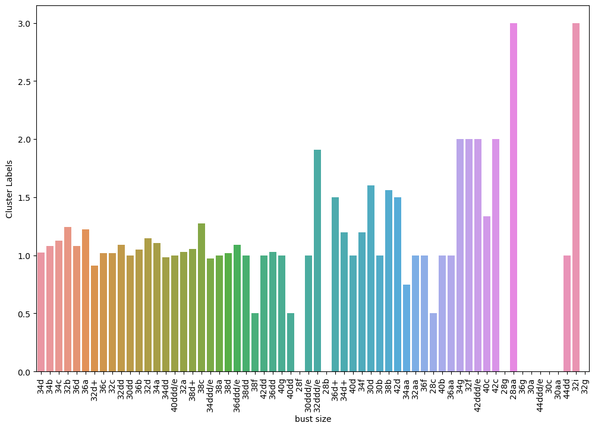

```python
#'bust size'

# Drop rows with non-finite values in the 'Labels' column
df_hier.dropna(subset=['Labels'], inplace=True)

# Convert 'Labels' column to integer type
df_hier['Labels'] = df_hier['Labels'].astype(int)
plt.figure(figsize=(12, 8))
sns.barplot(x='bust size', y='Labels', data=df_hier, ci=None, hue_order=[0, 1, 2, 3])
plt.xlabel('bust size')
plt.ylabel('Cluster Labels')
plt.xticks(rotation=90)
plt.show()
```